# Practice Session & Exercise

Introduction to R and Basic Programming Concepts

Author

Affiliation

Bioinformatics Core Facility CECAD

Published

May 21, 2026

# 1 Practice by Sessions

## 1.1 Session 1

### 1.1.1 Exercise 1:

- Use R to calculate the following:
  - multiply 31 and 78
  - divide 697 with 41
- Assign the value of 39 to x
- Assign the value of 22 to y

*Solution 1*.

```r
31 * 78
```

```
[1] 2418
```

```r
697 / 41
```

```
[1] 17
```

```r
x <- 39
x
```

```
[1] 39
```

```r
y <- 22
y
```

```
[1] 22
```

## 1.2 Session 2

**Before You Start : Some Raw Material**

Please copy the below code:

Assume you observed the expression of six genes under two conditions:

```r
C1 <- c(g1=0,  g2=1,  g3=10,  g4=6,  g5=4,  g6=23)
C2 <- c(g1=20, g2=11, g3=1,   g4=7,  g5=3,  g6=5)
```

In addition you have a grouping variable for the genes:

```r
G  <- c(g1="A",g2="A",g3="B", g4="C",g5="C",g6="B")
```

### 1.2.1 Exercise 1: Create a Matrix

Use the `cbind()` function (“column-wise bind”) to bind C1 and C2 into a matrix (if you are unsure, check `?cbind`).

Assign the result to a variable named “M” and print it.

Can you get the number of rows and columns of M using R code?

*Solution 2*.

```r
M <- cbind(C1,C2) # note that the variable names are now column names!
M
```

```
   C1 C2
g1  0 20
g2  1 11
g3 10  1
g4  6  7
g5  4  3
g6 23  5
```

```r
nrow(M) # the number of rows
```

```
[1] 6
```

```r
ncol(M) # the number of columns
```

```
[1] 2
```

### 1.2.2 Exercise 2: Data Type of a Matrix

What is the data type of M? Do you have an idea why actually two types are listed?

*Solution 3*.

```r
class(M)
```

```
[1] "matrix" "array"
```

```r
# M is both a matrix and also an array with a single slice!
```

### 1.2.3 Exercise 3: Inspect the Matrix

Extract the first column by index and by name. What is its data type?  
Use the `is.vector()` function to confirm that it is a vector.

Extract the second row by index and by name. What is its data type?  
Use the `is.vector()` function to confirm that it is a vector, too.

*Solution 4*.

```r
class(M[,1])
```

```
[1] "numeric"
```

```r
is.vector(M[,1])
```

```
[1] TRUE
```

```r
class(M[2,])
```

```
[1] "numeric"
```

```r
is.vector(M[2,])
```

```
[1] TRUE
```

### 1.2.4 Exercise 4a: Row Means by Hand

The operators “+” and “/” are vectorizing, that is, they can operate on entire vectors.

Get the mean expression of the 6 genes in the two conditions by adding C1 and C2, and then dividing the result by 2.

Assign the result to a variable named Cmean.

Hint: Put parentheses where needed, to ensure the correct order of computations!

*Solution 5*.

```r
C1C2_mean <- (C1+C2) / 2
C1C2_mean # note: just putting the variable name is often equivalent to using print()
```

```
  g1   g2   g3   g4   g5   g6
10.0  6.0  5.5  6.5  3.5 14.0
```

### 1.2.5 Exercise 4b: Row (and Column) Means Computationally

R has a function `rowMeans()`, which does exactly the computation of Exercise 4a. Try it and compare to C1C2_mean of Exercise 4a, using function `identical()`.

What do you think the pendant `colMeans()` does? Try it.

*Solution 6*.

```r
# Observe that each index in the vectors C1 and C2 correspond to a ROW in M
C1C2_mean_rowMeans <- rowMeans(M)
identical(C1C2_mean, C1C2_mean_rowMeans)
```

```
[1] TRUE
```

```r
columnMeans <- colMeans(M)
columnMeans
```

```
      C1       C2
7.333333 7.833333
```

### 1.2.6 Exercise 5: Type Conversion (Not Always Intended)

Try to `cbind()` all 3 vectors C1, C2, and G.  
It will work, but something goes wrong. Do you observe something unexpected?

*Solution 7*.

```r
cbind(C1,C2,G)
```

```
   C1   C2   G
g1 "0"  "20" "A"
g2 "1"  "11" "A"
g3 "10" "1"  "B"
g4 "6"  "7"  "C"
g5 "4"  "3"  "C"
g6 "23" "5"  "B"
```

```r
# A matrix is a 2D generalization of a vector, and like in a vector, all its
# elements must be of the same data type. If we try to mix truly
# incompatible data types, we get an error.
# But by an internal conversion rule numbers can be converted to text.
# Hence R, trying to be obedient and to make our matrix, converts all
# numbers to character values!
# Such things can be hard to spot if they happen unintentionally.
```

### 1.2.7 Exercise 6: Make a List

The `list()` function combines heterogeneous R objects into a common list object.

The names of the resulting list elements can be specified like so: `list(my_name=my_object)`.

Use the function to create a list of C1, C2, and G,  
with names “condition1”, “condition2”, and “group”.`

Assign the list object to a variable named “L” and print it.

*Solution 8*.

```r
L <- list(condition1 = C1,
          condition2 = C2,
          group = G)
# note that you can break a long command line anywhere,
# except in the middle of a word

L
```

```
$condition1
g1 g2 g3 g4 g5 g6
 0  1 10  6  4 23

$condition2
g1 g2 g3 g4 g5 g6
20 11  1  7  3  5

$group
 g1  g2  g3  g4  g5  g6
"A" "A" "B" "C" "C" "B"
```

```r
# All 3 objects have been "hooked onto" L, keeping their
# entire, original form
```

### 1.2.8 Exercise 7: Make a Dataframe

A list is convenient because of its permissiveness: you can store (nearly) anything there. But it can also be cumbersome to handle.

**List L has a special property: all of its elements are vectors of a fixed length (although of different data types).**  
Such lists can be transformed such that they look very similar to matrices, yet internally stay lists with all their benefits.  
This matrix-like data structure is the dataframe (data type `data.frame`).  
Convert L to a dataframe using `as.data.frame()`, assign the result to a variable named df, and print it.

*Solution 9*.

```r
df <- data.frame(L)
df
```

```
   condition1 condition2 group
g1          0         20     A
g2          1         11     A
g3         10          1     B
g4          6          7     C
g5          4          3     C
g6         23          5     B
```

### 1.2.9 Exercise 8a: Inspect the Dataframe

A dataframe can be indexed like a matrix.  
Extract the first column by index or by name, and use `class()` and `is.vector()` on it.  
Then do the same with the second row. Do both dimensions behave in the same way?

*Solution 10*.

```r
df[,1]
```

```
[1]  0  1 10  6  4 23
```

```r
class(df[,1])
```

```
[1] "numeric"
```

```r
is.vector(df[,1])
```

```
[1] TRUE
```

```r
# equivalent formulations:
# is.vector(df[,"condition1"])
# is.vector(df$condition1)

df[2,]
```

```
   condition1 condition2 group
g2          1         11     A
```

```r
class(df[2,])
```

```
[1] "data.frame"
```

```r
is.vector(df[2,])
```

```
[1] FALSE
```

### 1.2.11 Exercise 9: Make a Factor

Vector G (which is also the “group” column of df) is a grouping variable for the ratio of the count vectors C1 and C2:  
C2 is higher than C1 in group “A” of G, lower than C1 in group “B”, and about the same in group “C”.

We can make it explicit that it is a grouping variable by coding it as a factor.

In a much larger, real dataset, such a grouping factor for genes could be used to statistically relate gene induction or repression to some other attribute of the genes, for example to pathway membership.  
Here we simply practice to set up a factor variable:

*Solution 12*.

```r
f1 <- factor(G, levels = c("C","A","B"))
f1
```

```
g1 g2 g3 g4 g5 g6
 A  A  B  C  C  B
Levels: C A B
```

```r
f2 <- factor(G, levels = c("C","B","A"))
f2
```

```
g1 g2 g3 g4 g5 g6
 A  A  B  C  C  B
Levels: C B A
```

```r
df$group <- factor(G, levels = c("C","A","B"))
class(df$group)
```

```
[1] "factor"
```

## 1.3 Session 3

### 1.3.1 Exercise 1: R Control Flow (`if, if...else`)

You are analyzing the expression level of a target cancer gene ((p53)). You need to write a script that checks a scalar expression value and prints a diagnostic classification.

**Task:** Create a variable named p53_expr. Write an `if...else if...else` structure that:

1. Prints “Critical Overexpression” if p53_expr is strictly greater than 10.
2. Prints “Normal Expression” if p53_expr is between 3 and 10 (inclusive).
3. Prints “Underexpressed” if p53_expr is less than 3.

**Bonus Challenge:** Test your code by converting the structure into a vectorized function using `ifelse()` to handle an entire vector of expressions: c(12, 5, 1, 8, 15).

*Solution 13*.

```r
p53_expr <- 8
if (p53_expr > 10) {
  print("Critical Overexpression")
} else if (p53_expr >= 3) {
  print("Normal Expression")
} else {
  print("Underexpressed")
}
```

```
[1] "Normal Expression"
```

```r
# Bonus Vectorized Check
p53_vec <- c(12, 5, 1, 8, 15)
ifelse(p53_vec > 10, "Critical Overexpression",
       ifelse(p53_vec >= 3, "Normal Expression", "Underexpressed"))
```

```
[1] "Critical Overexpression" "Normal Expression"
[3] "Underexpressed"          "Normal Expression"
[5] "Critical Overexpression"
```

### 1.3.2 Exercise 2: R Loops (`for, next, break`)

You have a list of DNA primer sequences. You need to screen them sequentially. However, your laboratory pipeline must skip short sequences and completely halt if an invalid or contaminated sequence is detected.

**Task:** Write a `for` loop to iterate through `primers` and evaluate the text length using `nchar()`:

`primers <- c("ATGGC", "AT", "GTCGATC", "UNKNOWN", "CTGA","AYTGC")`

1. If a sequence matches unknown character, print “Contamination detected! Halting pipeline.” and exit the loop immediately.
2. If a sequence has fewer than 4 characters, skip it , print the message: `"Skipping short primer: [sequence_here]"` and continue to the next iteration.
3. For all valid sequences, print the message: `"Processing primer: [sequence_here]"`.

*Solution 14*.

```r
primers <- c("ATGGC", "AT", "GTCGATC", "UNKNOWN", "CTGA","AYTGC")
for (p in primers) {
  if (p == "UNKNOWN") {
    print("Contamination detected! Halting pipeline.")
    break
  }
  if (nchar(p) < 4) {
    print(paste("Skipping short primer:", p))
    next
  }
  print(paste("Processing primer:", p))
}
```

```
[1] "Processing primer: ATGGC"
[1] "Skipping short primer: AT"
[1] "Processing primer: GTCGATC"
[1] "Contamination detected! Halting pipeline."
```

### 1.3.3 Exercise 3: R Loops (`while or repeat`)

A bacterial culture starts with a population of 150 cells and doubles every hour. You need to determine exactly how many hours it takes for the colony to breach a critical biohazard threshold of 20,000 cells.

1. Initialize two variables: population <- 150 and hours <- 0.
2. Write a while loop that continues running as long as population is less than 20000.
3. Inside the loop, increment the hours counter by 1 and double the population.
4. After the loop terminates, print a final summary sentence showing the total hours and ending population.

**Bonus Challenge:** Modify your loop to include a safety check that halts the process if it exceeds 24 hours, printing “Process halted: Time limit exceeded.” and breaking the loop. Plot the population growth over time using a simple line graph.

*Solution 15*.

```r
population <- 150
hours <- 0
while (population < 20000) {
  hours <- hours + 1
  population <- population * 2

  if (hours > 24) {
    print("Process halted: Time limit exceeded.")
    break
  }
}

print(paste("Threshold breached at hour", hours, "with", population, "cells."))
```

```
[1] "Threshold breached at hour 8 with 38400 cells."
```

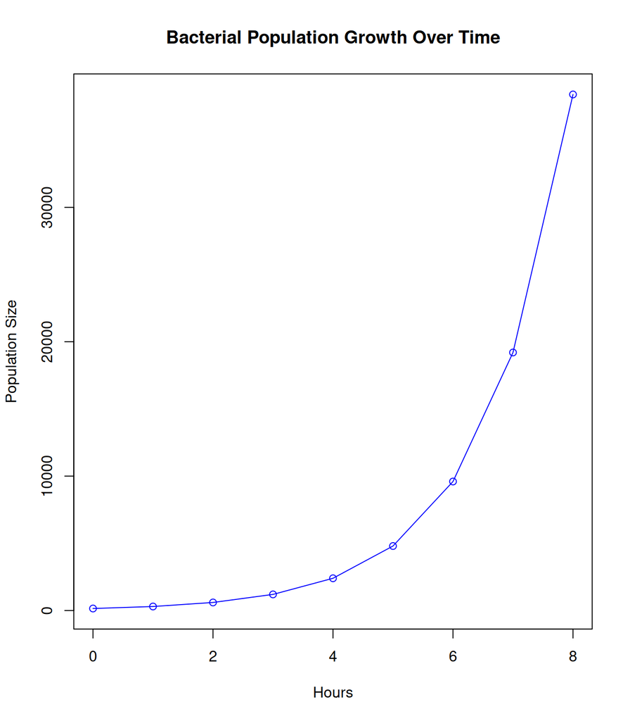

```r
# Bonus: Plotting population growth
population <- 150
hours <- 0

pop_growth <- data.frame(Hours = hours, Population = population)
while (population < 20000) {
  hours <- hours + 1
  population <- population * 2
  pop_growth <- rbind(pop_growth, data.frame(Hours = hours, Population = population))
  if (hours > 24) {
    print("Process halted: Time limit exceeded.")
    break
  }
}

plot(pop_growth$Hours, pop_growth$Population, type = "o", col = "blue",
     xlab = "Hours", ylab = "Population Size",
     main = "Bacterial Population Growth Over Time")
```

### 1.3.4 Exercise 4: `apply()` family function

You receive a 2D dataset tracking the concentrations of 4 different metabolites (columns) across 6 laboratory tissue samples (rows). You must extract the baseline variability for each metabolite.

**Task:** Copy this code to generate your matrix:

```r
set.seed(42)
metabolite_matrix <- matrix(rnorm(24, mean = 5, sd = 2), nrow = 6)
colnames(metabolite_matrix) <- c("Glucose", "Lactate", "Pyruvate", "Alanine")
```

1. Use a single `apply()` function call to compute the *median* concentration for each row (per tissue sample).
2. Use a second `apply()` function call to compute the *standard deviation (sd)* for each column (per metabolite type).

*Solution 16*.

```r
set.seed(42)
metabolite_matrix <- matrix(rnorm(24, mean = 5, sd = 2), nrow = 6)
colnames(metabolite_matrix) <- c("Glucose", "Lactate", "Pyruvate", "Alanine")

# Row medians (Margin = 1)
apply(metabolite_matrix, 1, median)
```

```
[1] 4.982098 4.626552 5.229807 5.570149 5.232351 6.108550
```

```r
# Column standard deviations (Margin = 2)
apply(metabolite_matrix, 2, sd)
```

```
 Glucose  Lactate Pyruvate  Alanine
1.317636 2.043521 2.324981 3.057981
```

## 1.4 Session 4

### 1.4.1 Exercise 1: CSV I/O & the factor gotcha

*Estimated time: 20 minutes*

A collaborator sends you a small gene expression table. The decimals are written with a comma and columns are separated by semicolons. You want to round-trip the file (write it, read it back) and make sure nothing changes silently — in particular, that character columns do not get converted to factors.

**Task:**

```r
expr <- data.frame(
  gene      = c("TP53", "BRCA1", "MYC", "EGFR", "KRAS"),
  condition = c("ctrl", "ctrl", "treat", "treat", "ctrl"),
  log2FC    = c(-0.42, 1.87, 2.31, -1.12, 0.05)
)
```

1. Write `expr` to a file `expr_de.csv` using `write.csv2()` (German-style: `;` separator, `,` decimal). Inspect the raw file content with `readLines("expr_de.csv")`.
2. Read the file back with `read.csv2()` into an object `expr_back`. Check `class(expr_back$gene)` — is it `character` or `factor`?
3. Re-read the file passing `stringsAsFactors = FALSE` (or convert with `as.character()`) so that `gene` and `condition` stay as character vectors.
4. Compare the two data frames with `identical(expr, expr_back)` and `all.equal(expr, expr_back)`. If they differ, explain why.

**Bonus Challenge:** Write the same data with the default `write.csv()` and read it back with `read.csv()`. Which separator and decimal symbol does each pair use? When would the German variant matter in practice?

*Solution 17*.

```r
expr <- data.frame(
  gene      = c("TP53", "BRCA1", "MYC", "EGFR", "KRAS"),
  condition = c("ctrl", "ctrl", "treat", "treat", "ctrl"),
  log2FC    = c(-0.42, 1.87, 2.31, -1.12, 0.05)
)

# 1. Write German-style CSV
write.csv2(expr, "expr_de.csv", row.names = FALSE)
readLines("expr_de.csv")
```

```
[1] "\"gene\";\"condition\";\"log2FC\"" "\"TP53\";\"ctrl\";-0,42"
[3] "\"BRCA1\";\"ctrl\";1,87"           "\"MYC\";\"treat\";2,31"
[5] "\"EGFR\";\"treat\";-1,12"          "\"KRAS\";\"ctrl\";0,05"
```

```r
# 2. Read back and check class
expr_back <- read.csv2("expr_de.csv")
class(expr_back$gene)
```

```
[1] "character"
```

```r
# 3. Force character columns
expr_back <- read.csv2("expr_de.csv", stringsAsFactors = FALSE)
class(expr_back$gene)
```

```
[1] "character"
```

```r
# 4. Compare
identical(expr, expr_back)
```

```
[1] TRUE
```

```r
all.equal(expr, expr_back)
```

```
[1] TRUE
```

```r
# Bonus: default CSV
write.csv(expr, "expr_us.csv", row.names = FALSE)
readLines("expr_us.csv")
```

```
[1] "\"gene\",\"condition\",\"log2FC\"" "\"TP53\",\"ctrl\",-0.42"
[3] "\"BRCA1\",\"ctrl\",1.87"           "\"MYC\",\"treat\",2.31"
[5] "\"EGFR\",\"treat\",-1.12"          "\"KRAS\",\"ctrl\",0.05"
```

```r
expr_us <- read.csv("expr_us.csv", stringsAsFactors = FALSE)
all.equal(expr, expr_us)
```

```
[1] TRUE
```

### 1.4.2 Exercise 2: Binary formats — `saveRDS` vs `save`

*Estimated time: 15 minutes*

After a long overnight analysis you want to checkpoint your results so a colleague can reload them tomorrow without rerunning anything. R offers two binary formats: `saveRDS()` / `readRDS()` (one object, assigned on read) and `save()` / `load()` (multiple objects, restored under their original names).

**Task:**

```r
deg_results <- data.frame(
  gene   = paste0("g", 1:6),
  log2FC = c(1.2, -0.8, 2.5, -1.7, 0.3, 0.0),
  padj   = c(0.001, 0.04, 0.0001, 0.02, 0.6, 0.9)
)
sample_info <- data.frame(
  sample_id = paste0("s", 1:4),
  group     = c("ctrl", "ctrl", "treat", "treat")
)
```

1. Save `deg_results` to `deg.rds` with `saveRDS()`. Reload it under a *different* name, `deg2 <- readRDS("deg.rds")`. Verify with `identical(deg_results, deg2)`.
2. Save both `deg_results` and `sample_info` together to `session.RData` with `save()`. Remove them from your workspace with `rm(deg_results, sample_info)` and confirm with `ls()`.
3. Reload them with `load("session.RData")`. Notice they reappear under their original names — you do **not** assign the result of `load()`.
4. Explain in one sentence: when would you prefer `.rds` over `.RData`?

*Solution 18*.

```r
deg_results <- data.frame(
  gene   = paste0("g", 1:6),
  log2FC = c(1.2, -0.8, 2.5, -1.7, 0.3, 0.0),
  padj   = c(0.001, 0.04, 0.0001, 0.02, 0.6, 0.9)
)
sample_info <- data.frame(
  sample_id = paste0("s", 1:4),
  group     = c("ctrl", "ctrl", "treat", "treat")
)

# 1. Single object
saveRDS(deg_results, "deg.rds")
deg2 <- readRDS("deg.rds")
identical(deg_results, deg2)
```

```
[1] TRUE
```

```r
# 2. Multiple objects
save(deg_results, sample_info, file = "session.RData")
rm(deg_results, sample_info)
ls()
```

```
 [1] "C1"                 "C1C2_mean"          "C1C2_mean_rowMeans"
 [4] "C2"                 "colorize"           "columnMeans"
 [7] "deg2"               "df"                 "expr"
[10] "expr_back"          "expr_us"            "f1"
[13] "f2"                 "G"                  "hours"
[16] "L"                  "M"                  "metabolite_matrix"
[19] "p"                  "p53_expr"           "p53_vec"
[22] "pop_growth"         "population"         "primers"
[25] "x"                  "y"
```

```r
# 3. Reload — original names restored
load("session.RData")
ls()
```

```
 [1] "C1"                 "C1C2_mean"          "C1C2_mean_rowMeans"
 [4] "C2"                 "colorize"           "columnMeans"
 [7] "deg_results"        "deg2"               "df"
[10] "expr"               "expr_back"          "expr_us"
[13] "f1"                 "f2"                 "G"
[16] "hours"              "L"                  "M"
[19] "metabolite_matrix"  "p"                  "p53_expr"
[22] "p53_vec"            "pop_growth"         "population"
[25] "primers"            "sample_info"        "x"
[28] "y"
```

```r
# 4. Prefer .rds when you want to control the variable name on read
#    (e.g. inside a function or a pipeline). Use .RData to checkpoint
#    several related objects at once.
```

### 1.4.3 Exercise 3: Reshaping a time-course experiment

*Estimated time: 25 minutes*

You have measured the expression of three genes at four time points. Your raw table is in **wide** format (one column per time point), but the plotting function you want to use later expects **long** format (one row per measurement).

**Task:**

```r
wide <- data.frame(
  gene = c("TP53", "BRCA1", "MYC"),
  t0   = c(1.0, 0.8, 1.2),
  t1   = c(1.4, 0.9, 2.1),
  t2   = c(2.1, 1.1, 3.5),
  t3   = c(3.0, 1.3, 5.0)
)
```

1. Reshape `wide` to long format with `reshape()` using `gene` as `idvar`, the four time columns as `varying`, `v.names = "expression"`, `timevar = "time"`, and `direction = "long"`. Store it in `long`.
2. Inspect `long` — how many rows does it have? Why?
3. Reshape `long` back to wide format and store it in `wide_back`.
4. Compare with `all.equal(wide, wide_back)`. If attributes differ, try `all.equal(wide, wide_back, check.attributes = FALSE)`.

**Bonus Challenge:** Use `stack()` on a *subset* of the wide table (e.g. `wide[, -1]`) and compare the result with what `reshape()` produced. When is `stack()` simpler? When does it fall short?

*Solution 19*.

```r
wide <- data.frame(
  gene = c("TP53", "BRCA1", "MYC"),
  t0   = c(1.0, 0.8, 1.2),
  t1   = c(1.4, 0.9, 2.1),
  t2   = c(2.1, 1.1, 3.5),
  t3   = c(3.0, 1.3, 5.0)
)

# 1. Wide -> long
long <- reshape(wide,
                varying  = c("t0", "t1", "t2", "t3"),
                v.names  = "expression",
                timevar  = "time",
                times    = c("t0", "t1", "t2", "t3"),
                idvar    = "gene",
                direction = "long")
long
```

```
          gene time expression
TP53.t0   TP53   t0        1.0
BRCA1.t0 BRCA1   t0        0.8
MYC.t0     MYC   t0        1.2
TP53.t1   TP53   t1        1.4
BRCA1.t1 BRCA1   t1        0.9
MYC.t1     MYC   t1        2.1
TP53.t2   TP53   t2        2.1
BRCA1.t2 BRCA1   t2        1.1
MYC.t2     MYC   t2        3.5
TP53.t3   TP53   t3        3.0
BRCA1.t3 BRCA1   t3        1.3
MYC.t3     MYC   t3        5.0
```

```r
# 2. 3 genes x 4 time points = 12 rows
nrow(long)
```

```
[1] 12
```

```r
# 3. Long -> wide
wide_back <- reshape(long,
                     idvar    = "gene",
                     timevar  = "time",
                     direction = "wide")
wide_back
```

```
          gene expression.t0 expression.t1 expression.t2 expression.t3
TP53.t0   TP53           1.0           1.4           2.1           3.0
BRCA1.t0 BRCA1           0.8           0.9           1.1           1.3
MYC.t0     MYC           1.2           2.1           3.5           5.0
```

```r
# 4. Compare (column names will differ: t0 vs expression.t0)
all.equal(wide, wide_back, check.attributes = FALSE)
```

```
[1] TRUE
```

```r
# Bonus
stack(wide[, -1])
```

```
   values ind
1     1.0  t0
2     0.8  t0
3     1.2  t0
4     1.4  t1
5     0.9  t1
6     2.1  t1
7     2.1  t2
8     1.1  t2
9     3.5  t2
10    3.0  t3
11    1.3  t3
12    5.0  t3
```

```r
# stack() is simpler when you only need a single value/group pair,
# but it loses the gene identifier — reshape() preserves it via idvar.
```

### 1.4.4 Exercise 4: Combining tables — `merge`, `cbind`, `rbind`

*Estimated time: 25 minutes*

You have two tables from the same experiment: gene-level counts and sample metadata. They share a `sample_id` column. You want to attach metadata to counts so that each row of counts knows which group it belongs to.

**Task:**

```r
counts <- data.frame(
  sample_id = c("s1", "s2", "s3", "s4"),
  TP53      = c(120, 95, 300, 280),
  MYC       = c(45,  60, 410, 390)
)
meta <- data.frame(
  sample_id = c("s1", "s2", "s3", "s4"),
  group     = c("ctrl", "ctrl", "treat", "treat"),
  batch     = c(1, 1, 2, 2)
)
```

1. Merge `counts` and `meta` by `sample_id` using `merge()`. Store the result in `full`. How many rows does it have?
2. Now duplicate the first row of `meta` (`meta_bad <- rbind(meta, meta[1, ])`) and merge again. How many rows do you get now? Explain the Cartesian product.
3. Use `cbind()` to add a new column `total <- counts$TP53 + counts$MYC` to `full`. Why does `cbind()` work safely here but would fail if you tried to bind `counts` and `meta` directly?
4. Build a second batch of two samples (`s5`, `s6`) with the same columns as `counts`, then `rbind()` it onto `counts`. Verify the result has 6 rows.

*Solution 20*.

```r
counts <- data.frame(
  sample_id = c("s1", "s2", "s3", "s4"),
  TP53      = c(120, 95, 300, 280),
  MYC       = c(45,  60, 410, 390)
)
meta <- data.frame(
  sample_id = c("s1", "s2", "s3", "s4"),
  group     = c("ctrl", "ctrl", "treat", "treat"),
  batch     = c(1, 1, 2, 2)
)

# 1. Clean merge
full <- merge(counts, meta, by = "sample_id")
nrow(full)   # 4
```

```
[1] 4
```

```r
# 2. Cartesian blow-up from a duplicated key
meta_bad <- rbind(meta, meta[1, ])
full_bad <- merge(counts, meta_bad, by = "sample_id")
nrow(full_bad)   # 5 — s1 appears twice on the right side
```

```
[1] 5
```

```r
# 3. cbind a derived column
full$total <- full$TP53 + full$MYC
full
```

```
  sample_id TP53 MYC group batch total
1        s1  120  45  ctrl     1   165
2        s2   95  60  ctrl     1   155
3        s3  300 410 treat     2   710
4        s4  280 390 treat     2   670
```

```r
# cbind on counts + meta would just glue columns positionally,
# duplicating sample_id and *assuming* the row order matches.
# merge() uses the key, which is safer.

# 4. rbind a new batch
new_batch <- data.frame(
  sample_id = c("s5", "s6"),
  TP53      = c(150, 200),
  MYC       = c(80,  110)
)
counts2 <- rbind(counts, new_batch)
nrow(counts2)   # 6
```

```
[1] 6
```

## 1.5 Session 5

**Before You Start**

Please re-create `species_tables`, `species_means`, `species_colors`, and `trait_colors` as given at the beginning of `Session5.R`. Try to understand each step of the computations!

### 1.5.1 Exercise 1:

We want to study the distances between members of the versicolor and the setosa population, and compare it to the distances between members of the versicolor and the virginia population. Given the assumed genotypes (virginia 4n, setosa 2n, and the hybrid versicolor 4n+2n = 6n), versicolor and virginica should be closer to each other than versicolor and setosa, because they share more alleles. Here we do it for one flower trait at a time (assigned to variable “feature”).

Take the difference between the vectors `species_tables$versicolor[[feature]]` `species_tables$setosa[[feature]]` and assign it to variable “d_vs”.

Take the difference between the vectors `species_tables$versicolor[[feature]]` `species_tables$virginica[[feature]]` and assign it to variable “d_vv”.

We want to produce a plot which shows histograms of both difference vectors on the same canvas. See lines 347-388 in Session5.R for hints.

*Solution 21*.

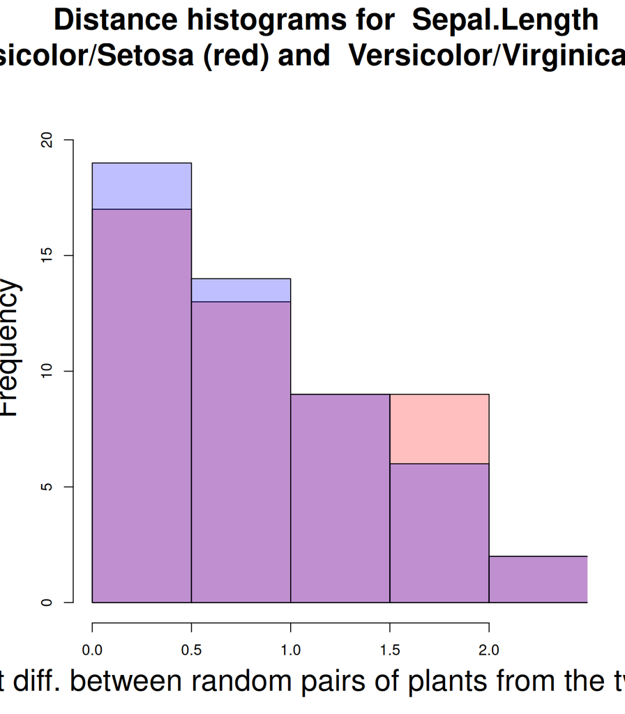

```r
species_tables <-
    split(iris[,-5],  ## what to split
          iris[, 5])  ## split by what


feature <- "Sepal.Length"
d_vs <-
  abs(species_tables$versicolor[[feature]] -
  species_tables$setosa[[feature]])
d_vv <-
  abs(species_tables$versicolor[[feature]] -
  species_tables$virginica[[feature]])

# total range of both vectors:
use_range <- c(min(c(d_vs,d_vv)),
               max(c(d_vs,d_vv)))

hist(d_vs,
     col=rgb(1,0,0,1/4),

     add=FALSE, ## this is the default

     ## initialize to full x range !
     xlim=use_range,

     ## full y range you usually
     ## only know after some trials ..
     ylim=c(0,22),

     ## x-axis label
     xlab="abs. trait diff. between random pairs of plants from the two species",

     ## larger axis labels:
     cex.lab = 2,

         main =
       paste("Distance histograms for ",
           feature,
             "\nVersicolor/Setosa (red) and ",                    "Versicolor/Virginica (blue)"),

     ## larger title:
     cex.main = 2
)


## ----Histogram_added2---------------------------------------------------------

hist(d_vv,
     add=TRUE,
     col=rgb(0,0,1,1/4)
)
```

### 1.5.2 Exercise 2: Label Extreme Points

Copy the code of Slide 17/Session5.html / Session5.R/lines 216-234.

Try the following: (1) Identify the 3 highest y values. (2) find all points which reach these values (these can be more than the 3 *unique* highest values, if multiple points have the same value). (3) mark all points found with a fat red point.

Hints: (1) We need function sort() for sorting all values. The sort should be decreasing, such that the highest values are on top. Check `?sort` to learn how a decreasing sort is selected. Then run `unique` on the sorted values, to remove repeated values. Finally assign the top 3 values of the sorted list to variable “top3”. (2) We saw the operator %in%, which is used as `"x %in% y"` and finds those points in vector x which are in vector y. Can you transfer this pattern to the task at hand? (3) Use the `points()` function to color the points red. Check `?points` to learn about parameters for choosing symbol, color and expansion factor. Try different values of the cex parameter.

*Solution 22*.

```r
df <- subset(iris, Species=="setosa")

plot(
# x is now the row number in df
x=1:nrow(df),
xlab="individual plant",
y=df$Petal.Width,
ylab="Petal.Width",
## show both points and
## connecting lines:
type="b",
## line width:
lwd = 2,
## line style = dashed:
lty=2,
main="Iris setosa"
)
sort(df$Petal.Width, decreasing = TRUE)[1:3]
```

```
[1] 0.6 0.5 0.4
```

```r
highest <- sort(df$Petal.Width, decreasing = TRUE)[1:3]
i <- which(df$Petal.Width %in% highest)
i
```

```
[1]  6 16 17 22 24 27 32 44 45
```

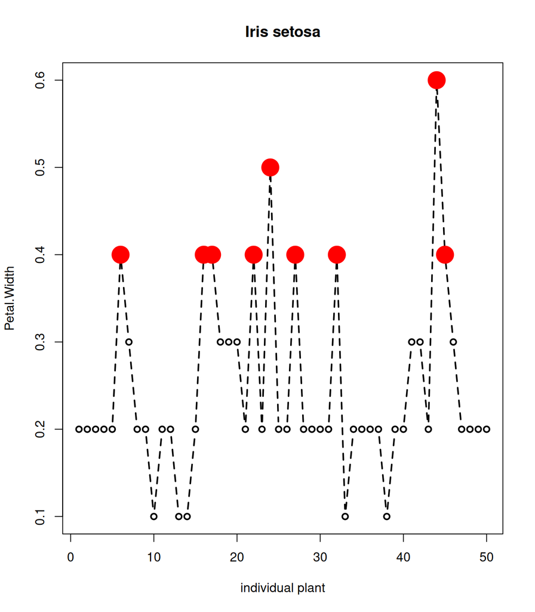

```r
points(i, df$Petal.Width[i], pch=21, col="red", bg="red", cex=3)
```